# 0. 의사결정나무

의사결정나무(decision trees) : 주어진 입력값들을 규칙에 따라 처리하여 출력값을 예측하는 트리구조의 모형

"분류나무(classification trees)"와 "회귀나무(regression trees)"는 의사결정나무 모형 중 하나이다.  
CART(classfication and regression trees) : 분류나무와 회귀나무를 통칭하는 말.

목표변수 y를 예측하기 위해 특성변수 $\mathbf{x}=(x_{1},x_{2},...,x_{d})^{T}$를 d차원상의 m개의 직사각형 셀로 공간을 분할한다.  
만약 y가 연속형이면 각 셀의 평균을 구해 회귀나무 완성  
만약 y가 K개의 범주이면 각 셀 내에서 가장 비중이 높은 범주로 y의 범주를 예측하여 분할나무 완성  
이렇게 학습데이터로 m개의 셀을 만들고 새로운 데이터는 단순히 어느 셀에 속하는지만 알면 새 데이터의 정밀도를 측정할 수 있다.

### 의사결정나무의 장점

- 해석이 직관적이고 간결하다.
- 분할기준이 구체적으로 제시되므로 해석이 명료하다

### 의사결정나무의 학습과정

- 특성변수 공간을 분할할 때 기준의 되는 변수($x_{1},x_{2}...$)를 어떤 순서로 사용할 것인가
- 그 변수에서 이항분할 값(노드,$t_{1},t_{2}...$)을 어떻게 정할 것인가

# 1. 회귀나무

### 회귀나무의 학습

[Step1]
특성변수의 관측치를 오름차순으로 정렬한다
[Step2]
정렬된 $x_{1}$의 관측치를 하나씩 노드로 하여 분할한 후, SSE를 구한다. 이때 $\overline{y}_{t}^{l}$와 $\overline{y}_{t}^{r}$은 해당 노드로 분할된 두개의 셀 각각의 평균이다.
이 SSE($x_{1}$)의 값이 가장 작은 $x_{1}$의 관측치를 $x_{1}$의 노드로 한다.
이 과정을 $x_{1}, x_{2}, ... x_{d}$에 대해 실시하여 각각 최소의 SSE($x_{1}$),...,SSE($x_{d}$)을 갖는 노드를 구한다 $$SSE(x_{1})= \sum_{i\in l}(y_{i}-\overline{y}_{t}^{l})^{2}+\sum_{i\in r}(y_{i}-\overline{y}_{t}^{r})^{2}$$
[Step3]
앞서 step2에서 구한 최소의 SSE($x_{1}$),...,SSE($x_{d}$) 중 가장 작은 값을 가진 특성변수의 노드로 분할한다.
[Step4]
앞서 step3의 분할 결과로 나온 각 영역 내에서 step1부터 step3을 반복한다.

### 회귀나무의 예측치

Step1부터 Step4를 반복한 결과로 $R_{1},...,R_{m}$의 셀들이 만들어졌다.
이때 새로운 관측치 $\mathbf{x}$에 대한 회귀나무의 예측치는 $$\hat{y}=\sum_{k=1}^{m}\overline{y}_{k}I(\mathbf{x}\in R_{k})$$
즉, 새로운 관측치가 속한 셀($I(\mathbf{x}\in R_{k})=1$인 셀)에 속해있는 학습데이터 y값의 평균($\overline{y}_{k}$)이 새 관측치에 대한 예측치이다

### 회귀나무의 손실함수

학습과정 Step2에서 SSE를 줄이는 방향으로 학습하는 것에서 알 수 있듯, 회귀나무의 손실함수는 SSE(sum of squared error)이다.

### 가지치기(pruning)

의사결정나무는 제한이 없다면 각 셀에 오직 하나의 학습데이터만 남을 때까지 학습과정을 반복하므로 과대적합이 발생한다.
따라서 분할의 깊이를 제한해줘야 하는데 이것이 가지치기(pruning)이다.
의사결정나무 T의 총 셀개수를 $|T|$라 할 때, 학습과정에서 $$C_{\alpha}(T)=\sum_{m=1}^{|T|}SSE_{m}+\alpha|T|$$ 가 최소인 T를 구함으로써 가지치기를 적용한다.
이때 $\alpha$는 가지치기를 어느정도 할지를 결정하는 초모수이다. $\alpha$값은 교차검증에 의해 결정한다

> $\alpha$가 크면, 셀 개수 $|T|$가 조금만 커져도 손실함수가 더욱 커진다. 즉, 손실함수를 최소화하는 학습 결과 선택된 의사결정나무는 $|T|$가 더욱 작은 나무이다.

# 2. 분류나무

분류나무는 y가 범주형이므로 손실함수로 회귀나무처럼 SSE를 사용하는 것은 적절하지 못함. 대신 불순도(impurity)를 사용

### 불순도 측도들

- Gini Index: $I_{G}(R_{m})=\sum_{k=1}^{K}\widehat{P}_{mk}(1-\widehat{P}_{mk})=1-\sum_{k=1}^{K}\widehat{P}_{mk}^{2}$
- Cross-Entropy: $I_{C}(R_{m})=-\sum_{k=1}^{K}\widehat{P}_{mk}\log_{2}(\widehat{P}_{mk})$
- Misclassification Error: $I_{E}(R_{m})=1-\widehat{P}_{mk_{m}}$

K: 총 범주 개수  
$\widehat{P}_{mk_{m}}$:셀 $R_{m}$내에 있는 클래스 중 가장 큰 비중을 갖는 클래스 $k_{m}$의 비율  
해당 셀이 불순도가 낮도록 잘 분류되어 있을수록 불순도 측도값이 작다

> 어떤 분류가 의미가 전혀 없을 때 불순도 측도는 최대가 된다. 불순도가 줄어들 때, 즉, $\widehat{P}_{1}$이 0 또는 1로 접근할 때 불순도 측도가 낮아진다

### 정보획득(IG : Information Gain)

부모 셀 R에서 나눠지는 두개의 영역 $R_{l}$과 $R_{r}$
R, $R_{l}$, $R_{r}$에 포함된 학습데이터의 개수 $N_{R}$, $N_{R_{l}}$, $N_{R_{r}}$
$$IG(R,x_{j})=I(R)-\frac{N_{R_{l}}}{N_{R}}I(R_{l})-\frac{N_{R_{r}}}{N_{R}}I(R_{r})$$ 자식영역이 불순도가 낮도록 잘 분류된 부모셀 R은 IG가 크다.

> 회귀나무는 "SSE($x_{j}$)가 최소가 되는 값"이 분할변수와 노드선택의 기준이었다면, 분류나무는 "IG(R,$x_{j}$)가 최대가 되는 값"이 선택의 기준이다

### 학습 및 예측과정

- 학습과정: 기본적으로 "SSE의 최솟값" 대신 "IG의 최댓값"을 사용할 뿐 회귀나무와 모형 구축과정은 동일하다.  
  따라서 학습과정에서 셀을 $x_{1}$부터 $x_{d}$까지 모든 변수들로 분할해 본다. 각 변수로 분할한 결과에 대해 각각 IG를 구해보고 IG가 최대가 되는 변수를 해당 셀을 분류하는 기준으로 채택한다. 이를 하위 셀들에 대해서도 반복해가며 모델을 완성한다.
- 예측과정: 새 관측치를 학습된 의사결정나무에 적용할 때, 관측치가 해당하는 셀에 있는 학습데이터의 클래스 중 가장 큰 비중을 갖는 클래스가 새 관측치의 클래스 예측치이다.

*분류나무의 학습과정에서는 IG를 구할 때 불순도 측도로 Gini index와 Cross-Entropy를 사용한다* 그러나 가지치기(pruning)에서는 불순도 측도로 Misclassification Error가 가장 효율적인 것으로 알려져있다. 회귀나무의 pruning 손실함수 식에 SSE$_{m}$ 대신 오분류오차를 사용한다.

## (+) CART(classification & regression tree)의 장점

1. 트리를 구성하는 특성변수가 연속형이든, 범주형이든 관계없이 동일하게 적용할 수 있다.
2. 특성변수의 이상치에 영향을 받지 않는다.

# 3. 의사결정나무 실습

iris data를 이용하여 CART 중 분류나무를 사용.

```python
#iris데이터 불러오기
import seaborn as sns
iris=sns.load_dataset('iris')
X=iris.drop('species', axis=1)   ##species변수를 제외한 변수들을 특성변수로 정의
y=iris['species']                ##species변수를 목적변수로 정의

#목적변수 species를 label encoding
from sklearn.preprocessing import LabelEncoder
classle=LabelEncoder()
y=classle.fit_transform(iris['species'].values)

#학습데이터와 시험 데이터를 7:3(testsize=0.3)으로 층화추출
from sklearn.model_selection import train_test_split
X_train, X_test, y_train, y_test=train_test_split(X,y,test_size=0.3, random_state=1, stratify=y)
```

DecisonTreeClassifier를 호출. 불순도 측도는 gini계수 사용. 나무의 깊이는 3으로 지정

```python
from sklearn import tree
dtc = tree.DecisionTreeClassifier(criterion='gini', max_depth=3, random_state=1)
dtc.fit(X_train, y_train)   #학습데이터로 분류나무 학습
y_train_pred=dtc.predict(X_train)   #training 데이터 예측
y_test_pred=dtc.predict(X_test)     #test 데이터 예측
```

[output not shown]

```python
from sklearn import metrics
print(metrics.accuracy_score(y_train, y_train_pred))
print(metrics.confusion_matrix(y_train, y_train_pred))
```

```
0.9523809523809523
[[35  0  0]
 [ 0 34  1]
 [ 0  4 31]]
```

```python
from sklearn import metrics
print(metrics.accuracy_score(y_test, y_test_pred))
print(metrics.confusion_matrix(y_test, y_test_pred))
```

```
0.9777777777777777
[[15  0  0]
 [ 0 15  0]
 [ 0  1 14]]
```

정밀도는 상당히 높게 나타남. 다만 test데이터에서보다 train데이터에서의 정밀도가 낮게 나온 것으로 보아 max_depth를 증가해 봐도 좋다.

### 분류나무그림 : 분류나무에서 각 노드가 어떤 변수의 어떤 값에 의해 만들어졌는지 보여주는 나무그림

학습데이터로 학습이 끝나면 분류나무그림을 그리는 것이 가능해진다.

```
[Text(0.3333333333333333, 0.875, 'x[3] <= 0.75\ngini = 0.667\nsamples = 105\nvalue = [35, 35, 35]'),
```

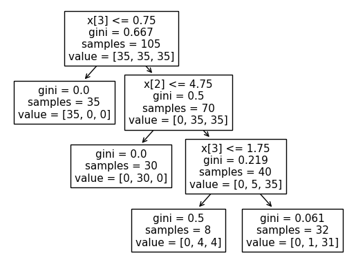

```python
tree.plot_tree(dtc.fit(X_train, y_train))
```

회귀나무도 from sklearn.tree import DecisionTreeRegression을 호출하여 분류나무와 동일한 방법으로 사용 가능하다.  
다만 회귀나무는 가지치기 정도를 결정하는 초모수 $\alpha$를 교차검증으로 지정해주는 것이 좋다. (교차검증 참고)